# Lab Module 6 - Analyze SNV Data

Fong Chun Chan (fongchunchan@gmail.com; @fongchunchan)

27 May, 2016

# 1 Introduction

Inside of RStudio when you click the **Knit** button in the document, it will be generate an html includes both content as well as the output of any embedded R code chunks within the document.

We will be using this R Markdown document to explore the SNV data from HCC1395 in more detail. First let’s load some packages that are needed:

```r
library("data.table")
library("ggplot2")
library("plyr")
library("dplyr")
library("stringr")
```

# 2 Strelka Analysis

Let’s start by loading the Strelka results. Some pre-processing is done on the tabular results to make them easier to work with. See if you can understand what is happening:

```r
strelkaDt <- fread("HCC1395.strelka.full.txt", header = T)

# rename columns so easier to reference later on
setnames(strelkaDt, "#CHROM", "CHROM")
setnames(strelkaDt, colnames(strelkaDt), gsub("GEN\\[0\\]", "normal", colnames(strelkaDt)))
setnames(strelkaDt, colnames(strelkaDt), gsub("GEN\\[1\\]", "tumour", colnames(strelkaDt)))

# convert CHROM variable in an ordered factor
strelkaDt <- strelkaDt[, CHROM := factor(CHROM, levels = c(1:22, "X"))]

# Converting QSS scores to probability
strelkaDt <- strelkaDt[, QSS_prob := round(1-10^(-QSS_NT/10), 3)]

# Generating allelic ratios
# Strelka returns the number of reads in tier1 and tier2 for each base
# We need to parse this information to retrieve the tumour read depth for the
# most probable variant allele at this position
tumour.AU.tier1 <- str_split(strelkaDt[, tumour.AU], ",") %>%
  lapply("[[", 1) %>%
  unlist %>%
  as.numeric

tumour.CU.tier1 <- str_split(strelkaDt[, tumour.CU], ",") %>%
  lapply("[[", 1) %>%
  unlist %>%
  as.numeric

tumour.GU.tier1 <- str_split(strelkaDt[, tumour.GU], ",") %>%
  lapply("[[", 1) %>%
  unlist %>%
  as.numeric

tumour.TU.tier1 <- str_split(strelkaDt[, tumour.TU], ",") %>%
  lapply("[[", 1) %>%
  unlist %>%
  as.numeric

strelkaDt <- strelkaDt[, tumour.AU := tumour.AU.tier1]
strelkaDt <- strelkaDt[, tumour.CU := tumour.CU.tier1]
strelkaDt <- strelkaDt[, tumour.GU := tumour.GU.tier1]
strelkaDt <- strelkaDt[, tumour.TU := tumour.TU.tier1]
strelkaDt <- strelkaDt[ALT == "A", tumour.AR := tumour.AU / tumour.DP]
strelkaDt <- strelkaDt[ALT == "C", tumour.AR := tumour.CU / tumour.DP]
strelkaDt <- strelkaDt[ALT == "G", tumour.AR := tumour.GU / tumour.DP]
strelkaDt <- strelkaDt[ALT == "T", tumour.AR := tumour.TU / tumour.DP]

# apply the following filters:
# 1) only consider autosome chromosomes
# 2) remove outlier high-coverage positions
# 3) multiple variant allele positions are ignored for simplicity
strelkaDt.filtered <- strelkaDt %>%
  filter(CHROM %in% c(1:22, "X")) %>%
  filter(tumour.DP < 200) %>%
  filter(ALT %in% c("A", "C", "T", "G"))
```

## 2.1 Mutational Load

Let’s look at the mutational load (i.e. number of mutations) across the genome.

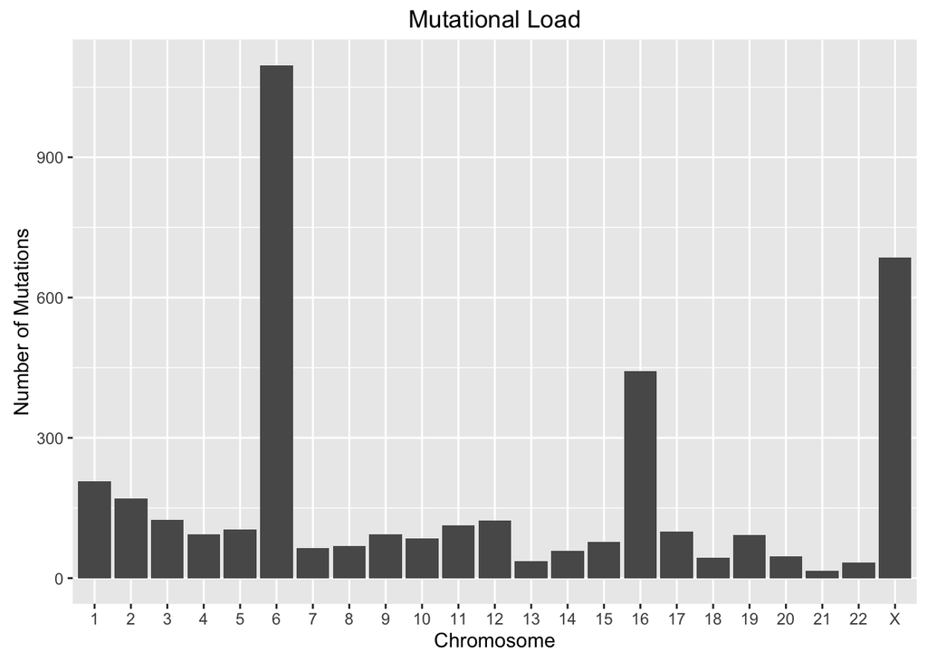

```r
strelkaDt.filtered %>%
  ggplot(aes(x = CHROM)) +
  geom_bar() +
  xlab("Chromosome") +
  ylab("Number of Mutations") +
  ggtitle("Mutational Load")
```

It seems that chromosomes 6, 16, and X appear to harbour the largest number of SNVs across all chromosomes.

## 2.2 Allelic Ratio

Let’s take a look at the allelic ratio of these mutations now.

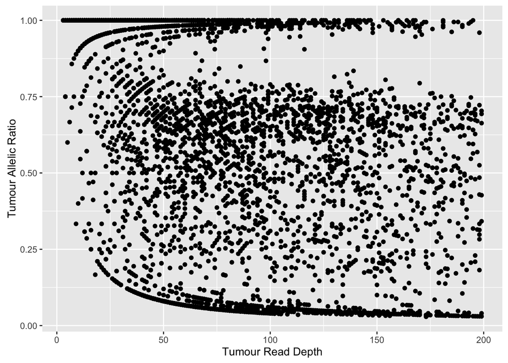

```r
strelkaDt.filtered %>%
  ggplot(aes(x = tumour.DP, y = tumour.AR)) +
  geom_point() +
  xlab("Tumour Read Depth") +
  ylab("Tumour Allelic Ratio")
```

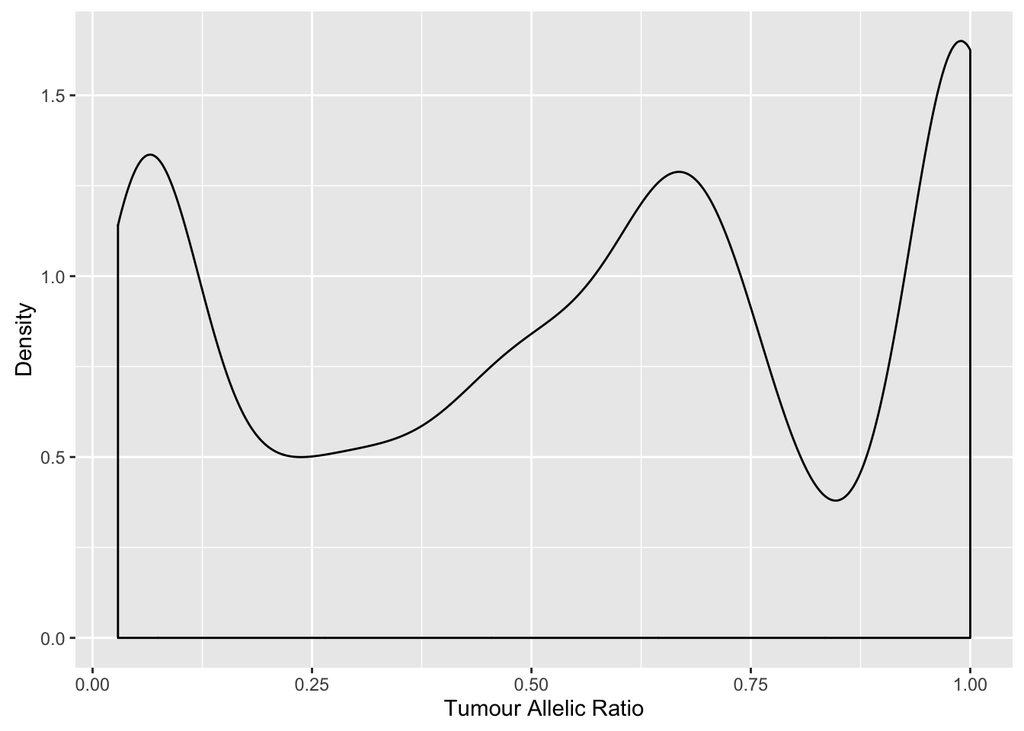

```r
strelkaDt.filtered %>%
  ggplot(aes(x = tumour.AR)) +
  geom_density() +
  xlab("Tumour Allelic Ratio") +
  ylab("Density")
```

There appears to be quite a widespread of allelic ratios in the sample. The allelic ratio sitting on the lower end of the range may potentially be false positives.

> Why don’t we see “humps” in the density distribution at 0.5 allelic ratio?

## 2.3 Substitution Patterns

Let’s look at some of the substitution patterns:

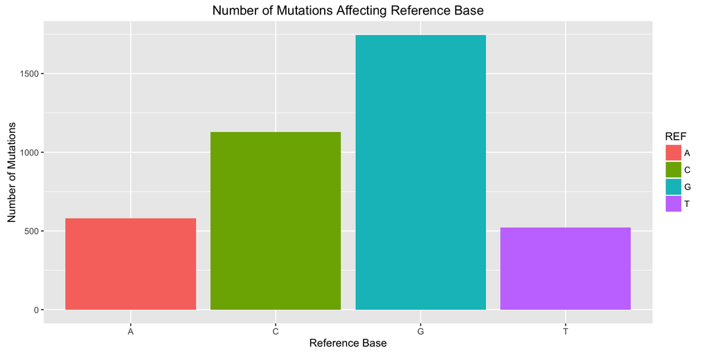

```r
strelkaDt.filtered %>%
  ggplot(aes(x = REF, fill = REF)) +
  geom_bar() +
  xlab("Reference Base") +
  ylab("Number of Mutations") +
  ggtitle("Number of Mutations Affecting Reference Base")
```

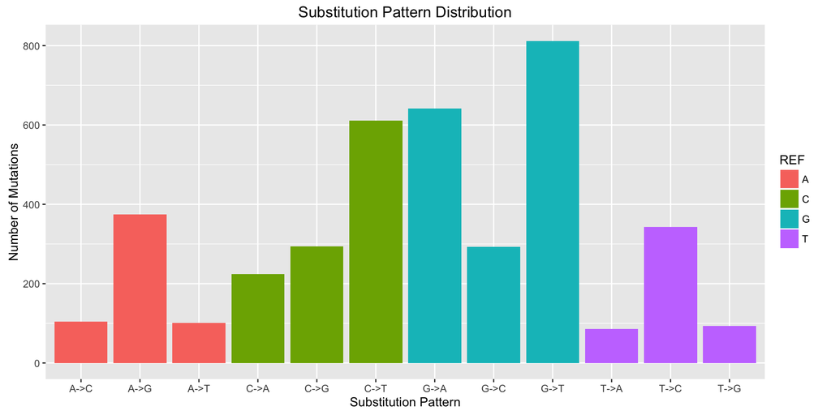

```r
strelkaDt.filtered %>%
  mutate(subPattern = str_c(REF, "->", ALT)) %>%
  ggplot(aes(x = subPattern, fill = REF)) +
  geom_bar() +
  xlab("Substitution Pattern") +
  ylab("Number of Mutations") +
  ggtitle("Substitution Pattern Distribution")
```

These plots suggest that mutations affecting the reference base G occur the most. Specifically, G->T appears to the most prevalent mutation pattern.

Now let’s take a look at these substitution patterns across the different chromosomes.

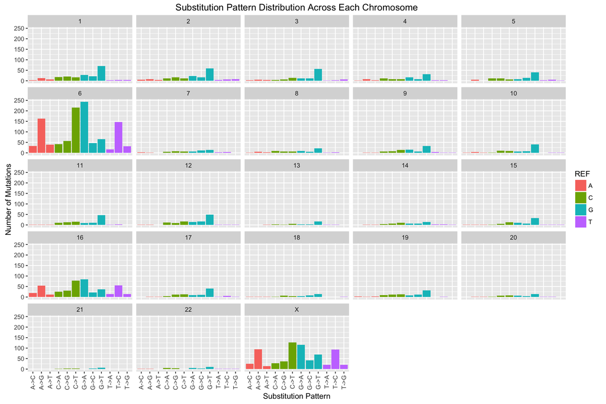

```r
strelkaDt.filtered %>%
  mutate(subPattern = str_c(REF, "->", ALT)) %>%
  ggplot(aes(x = subPattern, fill = REF)) +
  geom_bar() +
  facet_wrap(~ CHROM) +
  theme( axis.text.x = element_text(angle = 90, hjust = 1, vjust = 0.5)) +
  xlab("Substitution Pattern") +
  ylab("Number of Mutations") +
  ggtitle("Substitution Pattern Distribution Across Each Chromosome")
```

# 3 MutationSeq Analysis

Let’s analyze the MutationSeq results now. Load the MutationSeq predicted SNVs. These have been filtered for `PR > 0.85`.

```r
museqDt <- fread("HCC1395.museq.full.txt", header = TRUE)
setnames(museqDt, "#CHROM", "CHROM")
museqDt <- museqDt[, CHROM := factor(CHROM, levels = c(1:22, "X"))]
museqDt <- museqDt %>%
  mutate(TA.AR = TA / (TR + TA),
         T.DP = TR + TA )

museqDt.filtered <- museqDt %>%
  filter(CHROM %in% c(1:22, "X")) %>%
  filter(T.DP <= 200) %>%
  filter(ALT %in% c("A", "C", "T", "G"))
```

## 3.1 Mutational Load

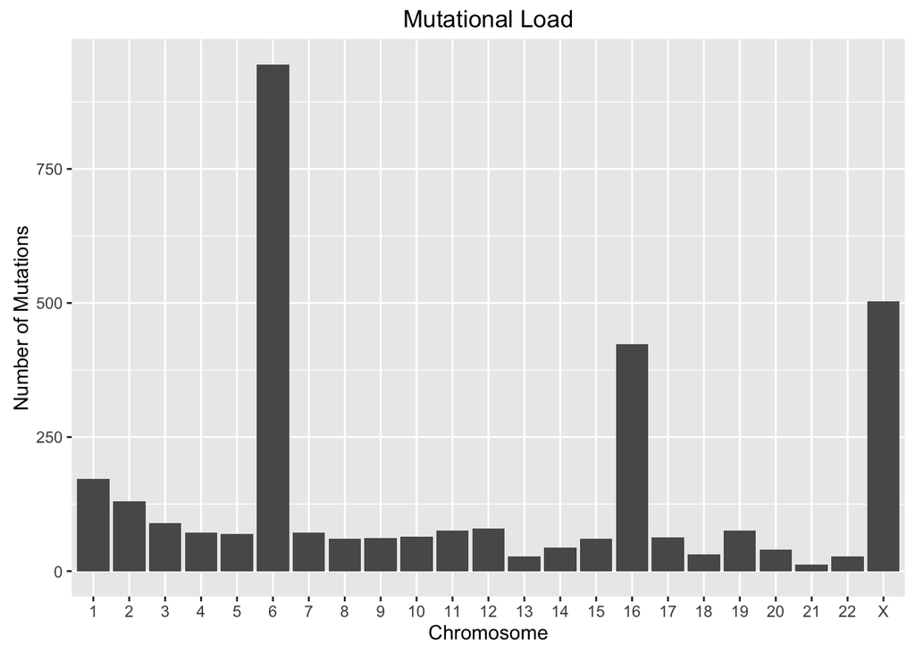

```r
museqDt.filtered %>%
  ggplot(aes(x = CHROM)) +
  geom_bar() +
  xlab("Chromosome") +
  ylab("Number of Mutations") +
  ggtitle("Mutational Load")
```

The mutational load across the different chromosomes is very similar to what we saw from the Strelka results.

## 3.2 Allelic Ratio

Let’s take a look at the allelic ratio of these mutations now.

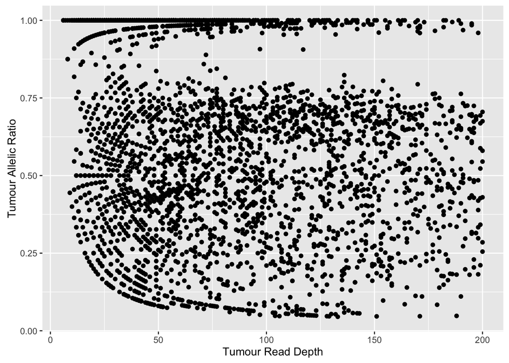

```r
museqDt.filtered %>%
  ggplot(aes(x = T.DP, y = TA.AR)) +
  geom_point() +
  xlab("Tumour Read Depth") +
  ylab("Tumour Allelic Ratio")
```

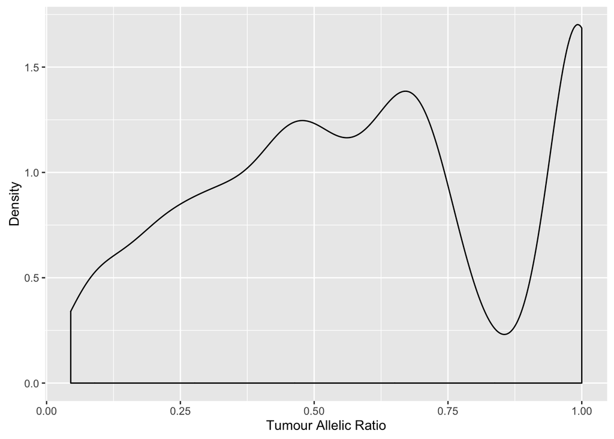

```r
museqDt.filtered %>%
  ggplot(aes(x = TA.AR)) +
  geom_density() +
  xlab("Tumour Allelic Ratio") +
  ylab("Density")
```

Again very similar to what we saw from the Strelka results.

## 3.3 Substitution Patterns

Let’s look at some of the substitution patterns:

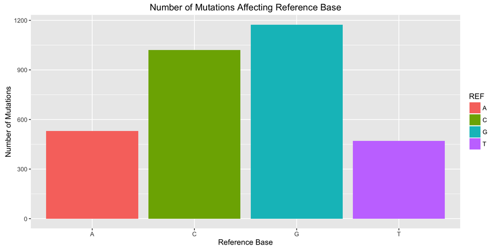

```r
museqDt.filtered %>%
  ggplot(aes(x = REF, fill = REF)) +
  geom_bar() +
  xlab("Reference Base") +
  ylab("Number of Mutations") +
  ggtitle("Number of Mutations Affecting Reference Base")
```

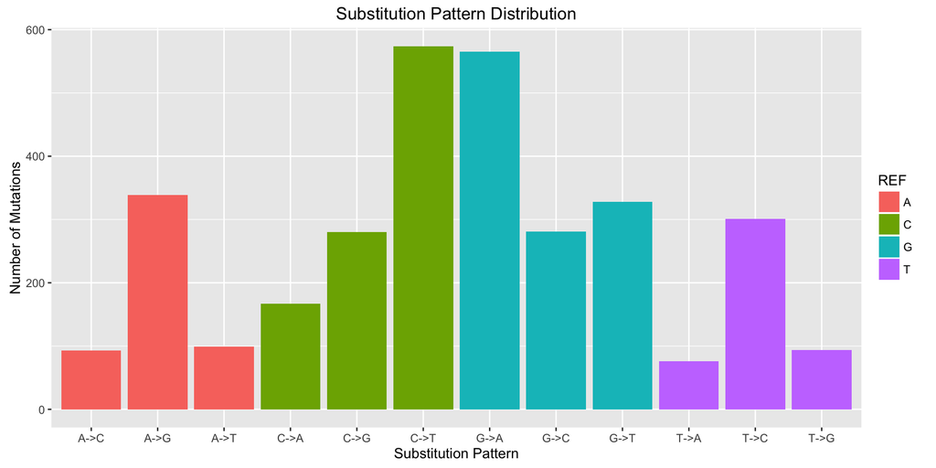

```r
museqDt.filtered %>%
  mutate(subPattern = str_c(REF, "->", ALT)) %>%
  ggplot(aes(x = subPattern, fill = REF)) +
  geom_bar() +
  xlab("Substitution Pattern") +
  ylab("Number of Mutations") +
  ggtitle("Substitution Pattern Distribution")
```

Similar to the Strelka results, we see that G-> mutations appear to be most common from the MutationSeq predictions. However, the most prevalent of these mutations is G->A mutations and not G->T as predicted by Strelka.

Let’s impose these substitution patterns across the different chromosomes:

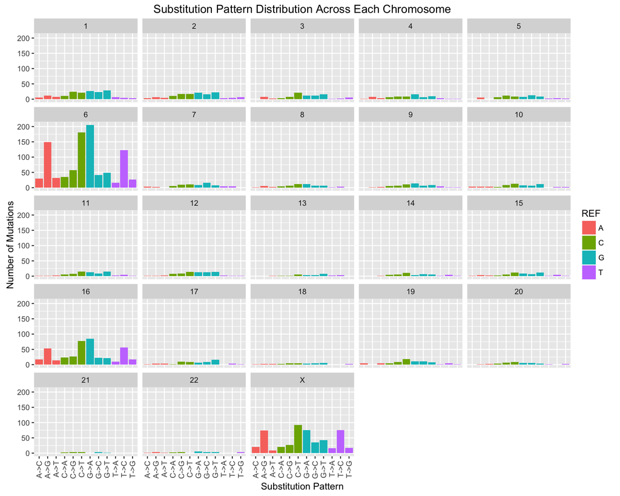

```r
museqDt.filtered %>%
  mutate(subPattern = str_c(REF, "->", ALT)) %>%
  ggplot(aes(x = subPattern, fill = REF)) +
  geom_bar() +
  facet_wrap(~ CHROM) +
  theme( axis.text.x = element_text(angle = 90, hjust = 1, vjust = 0.5)) +
  xlab("Substitution Pattern") +
  ylab("Number of Mutations") +
  ggtitle("Substitution Pattern Distribution Across Each Chromosome")
```

MutationSeq also returns the trinucleotide context of each mutation. We can plot such data:

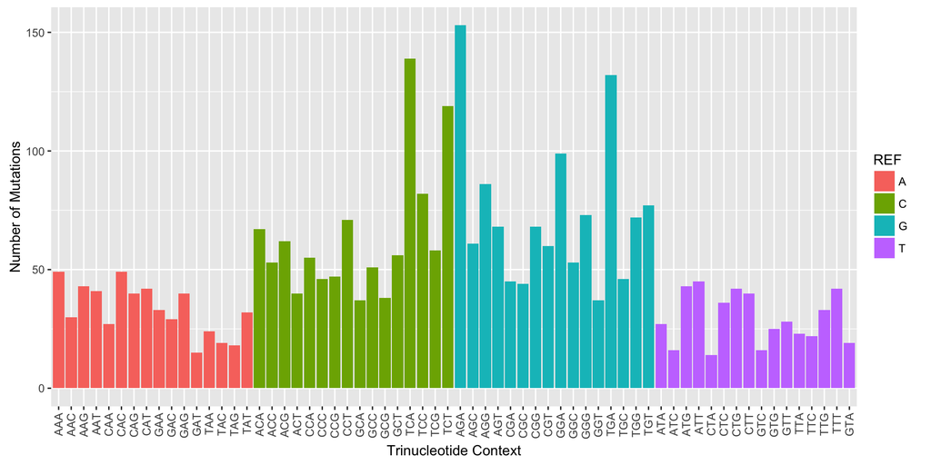

```r
TC.levels <- museqDt.filtered %>%
  arrange(REF, ALT, TC) %>%
  select(TC) %>%
  distinct %>%
  .$TC

museqDt.filtered %>%
  ggplot(aes(x = factor(TC, levels = TC.levels), fill = REF)) +
  geom_bar() +
  theme( axis.text.x = element_text(angle = 90, hjust = 1, vjust = 0.5)) +
  xlab("Trinucleotide Context") +
  ylab("Number of Mutations")
```

Here we are plotting the number of mutations in each trinucleotide context for each substitution pattern.

> There are 12 possible single base mutations (i.e. C->A, C->G, etc). Yet we show only 6 of them. Why is this?